# Early Childhood Program Evaluation: A Regression Analysis of WIC and AFDC Effects on Child Academic Achievement

### Assumption Diagnostics

**Linearity** — Scatterplots of mathraw97 against each predictor:

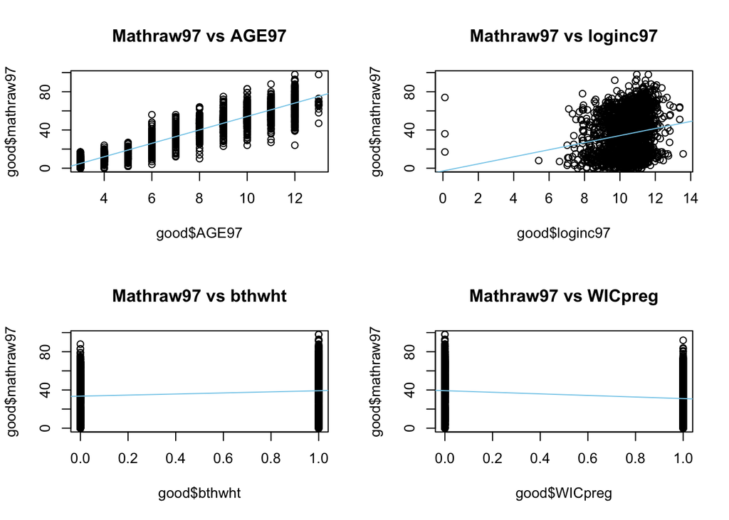

```r
par(mfrow = c(2, 2))
plot(good$AGE97, good$mathraw97, main = "Mathraw97 vs AGE97")
abline(lm(mathraw97 ~ AGE97, data = good), col = "skyblue")
plot(good$loginc97, good$mathraw97, main = "Mathraw97 vs loginc97")
abline(lm(mathraw97 ~ loginc97, data = good), col = "skyblue")
plot(good$bthwht, good$mathraw97, main = "Mathraw97 vs bthwht")
abline(lm(mathraw97 ~ bthwht, data = good), col = "skyblue")
plot(good$WICpreg, good$mathraw97, main = "Mathraw97 vs WICpreg")
abline(lm(mathraw97 ~ WICpreg, data = good), col = "skyblue")
```

**Homoscedasticity** — Residuals vs. fitted values:

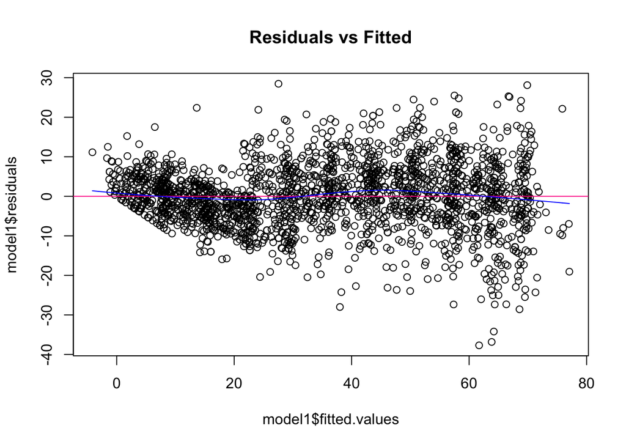

```r
plot(model1$fitted.values, model1$residuals, main = "Residuals vs Fitted")
abline(h = 0, col = "deeppink")
lines(lowess(model1$fitted.values, model1$residuals), col = "blue")
```

**Normality of Residuals:**

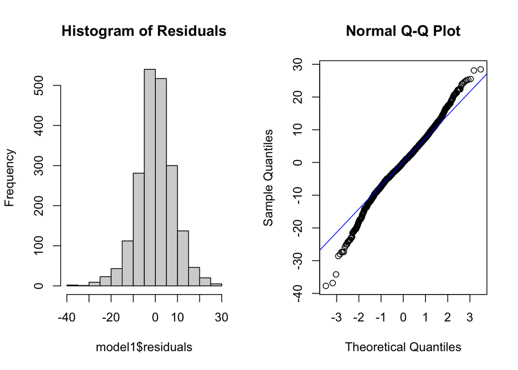

```r
par(mfrow = c(1, 2))
hist(model1$residuals, breaks = 20, main = "Histogram of Residuals")
qqnorm(model1$residuals)
qqline(model1$residuals, col = "blue")
```

### Outlier Diagnostics

**Studentized Residuals** (threshold: ±3):

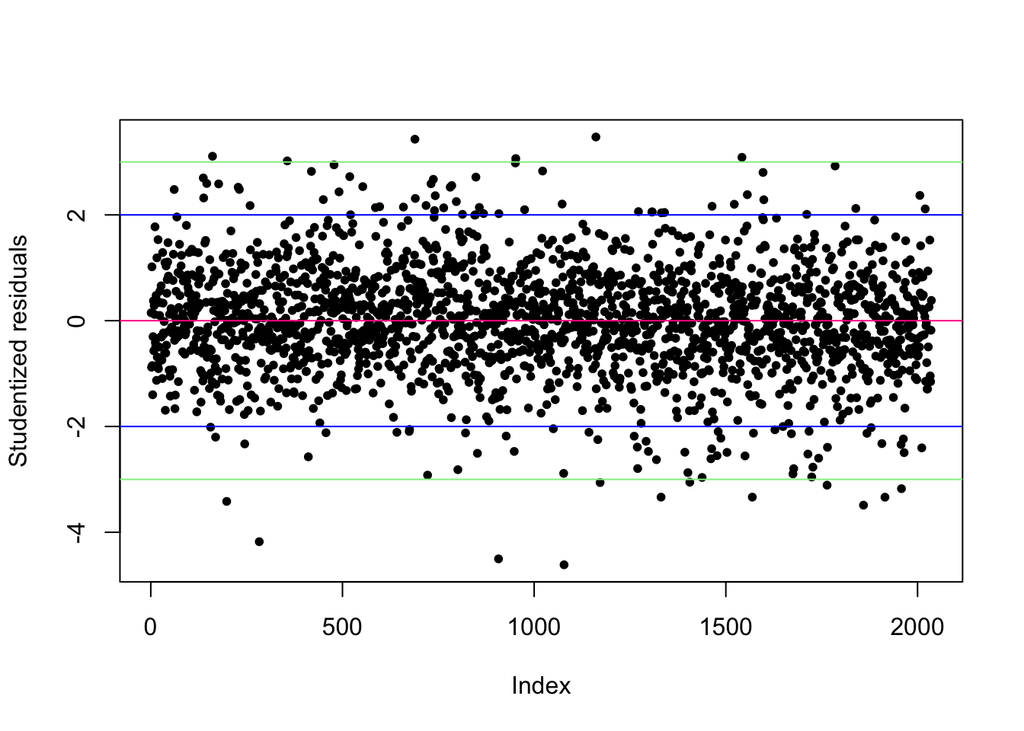

```r
good$index <- 1:nrow(good)
good$rstudent <- rstudent(model1)

plot(good$rstudent, xlab = "Index", ylab = "Studentized residuals", pch = 20)
abline(h = 0, col = "deeppink")
abline(h = c(2, -2), col = "blue")
abline(h = c(3, -3), col = "lightgreen")
```

```r
outliers_residuals <- subset(good, abs(good$rstudent) > 3)
print(outliers_residuals$index)
```

```
##  [1]  161  198  283  356  689  907  952 1078 1161 1172 1331 1406 1542 1569 1764
## [16] 1859 1915 1958
```

**Leverage Values** (threshold: 0.03):

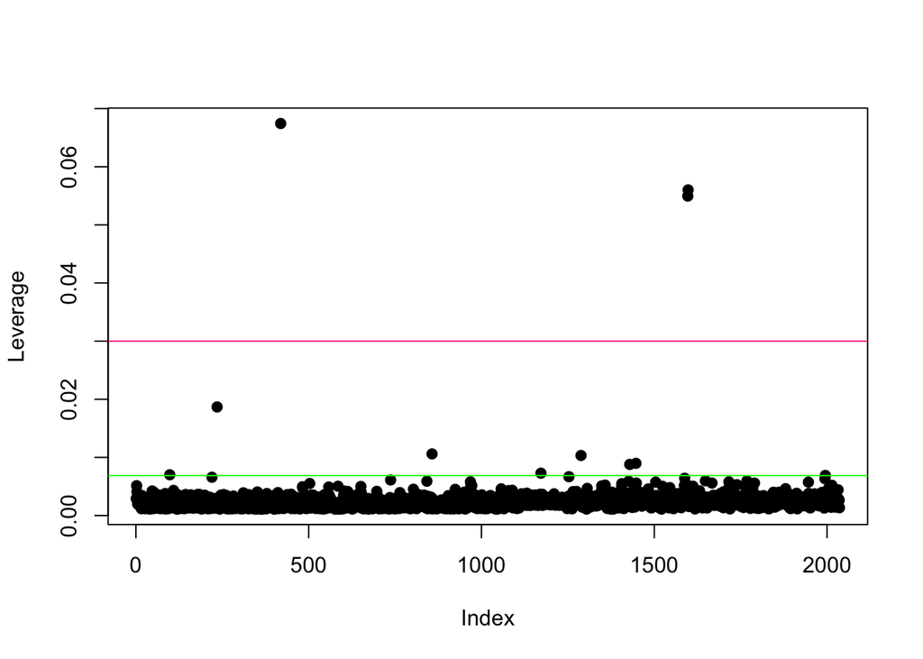

```r
cutoff_leverage <- (2 * (ncol(good) - 1)) / nrow(good)
good$leverage <- hatvalues(model1)

plot(good$leverage, xlab = "Index", ylab = "Leverage", pch = 19)
abline(h = cutoff_leverage, col = "green")
abline(h = 0.03, col = "deeppink")
```

```r
outliers_leverage <- subset(good, good$leverage > 0.03)
print(outliers_leverage$index)
```

```
## [1]  419 1597 1598
```

**Cook’s Distance** (threshold: 4/n):

```r
cutoff_cooksd <- 4 / nrow(good)
good$cooksd <- cooks.distance(model1)

influential_points <- subset(good, good$cooksd > cutoff_cooksd)
print(influential_points$index)
```

```
##   [1]   68   93  137  146  161  169  177  198  228  235  245  254  259  283  356
##  [16]  411  419  457  463  478  484  491  503  519  553  586  642  675  689  718
##  [31]  722  731  737  764  781  801  821  845  848  852  857  907  927  948  951
##  [46]  952  975 1022 1050 1073 1077 1078 1127 1143 1161 1166 1170 1172 1269 1270
##  [61] 1292 1298 1307 1319 1331 1340 1393 1401 1405 1406 1429 1438 1453 1461 1463
##  [76] 1469 1477 1480 1487 1503 1504 1522 1531 1542 1548 1550 1569 1572 1596 1597
##  [91] 1598 1599 1601 1628 1664 1671 1675 1677 1711 1714 1717 1724 1727 1742 1764
## [106] 1765 1785 1798 1839 1859 1868 1879 1880 1907 1915 1957 1958 1963 1965 2006
## [121] 2011 2020 2032
```

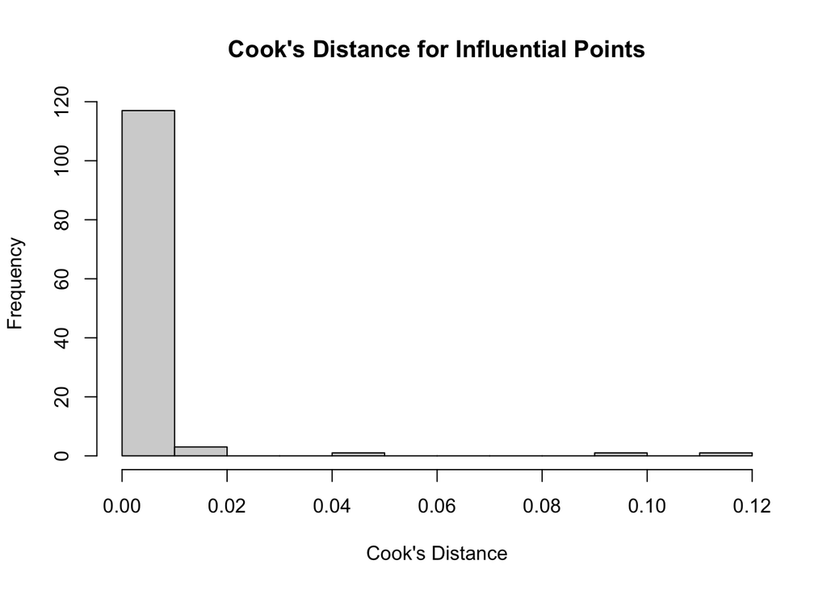

```r
hist(good$cooksd[good$cooksd > cutoff_cooksd],
     main = "Cook's Distance for Influential Points",
     xlab = "Cook's Distance",
     breaks = 10)
```

```r
cook_quantiles <- round(quantile(good$cooksd[good$cooksd > cutoff_cooksd], probs = seq(0, 1, 0.05)), 4)
print(cook_quantiles)
```

```
##     0%     5%    10%    15%    20%    25%    30%    35%    40%    45%    50%
## 0.0020 0.0020 0.0021 0.0022 0.0022 0.0023 0.0024 0.0025 0.0026 0.0028 0.0029
##    55%    60%    65%    70%    75%    80%    85%    90%    95%   100%
## 0.0032 0.0034 0.0035 0.0038 0.0043 0.0046 0.0057 0.0069 0.0097 0.1148
```

### Corrected Model and HOME97 Inclusion

Observations flagged by any of the three outlier criteria are removed. A third model adds HOME97 (home environment quality) to assess its incremental contribution.

```r
good_clean <- good[!(good$index %in% c(outliers_residuals$index,
                                        outliers_leverage$index,
                                        influential_points$index)), ]
nrow(good_clean)
```

```
## [1] 1913
```

```r
model2_corrected <- lm(mathraw97 ~ AGE97 + loginc97 + bthwht + WICpreg, data = good_clean)
summary(model2_corrected)
```

```
##
## Call:
## lm(formula = mathraw97 ~ AGE97 + loginc97 + bthwht + WICpreg,
##     data = good_clean)
##
## Residuals:
##      Min       1Q   Median       3Q      Max
## -18.2707  -4.5297   0.0185   4.6216  20.9594
##
## Coefficients:
##              Estimate Std. Error t value Pr(>|t|)
## (Intercept) -35.50362    2.07254 -17.131  < 2e-16 ***
## AGE97         7.18980    0.05444 132.061  < 2e-16 ***
## loginc97      1.93277    0.18735  10.317  < 2e-16 ***
## bthwht       -2.04816    0.32123  -6.376 2.27e-10 ***
## WICpreg      -2.28068    0.36047  -6.327 3.11e-10 ***
## ---
## Signif. codes:  0 '***' 0.001 '**' 0.01 '*' 0.05 '.' 0.1 ' ' 1
##
## Residual standard error: 6.66 on 1908 degrees of freedom
## Multiple R-squared:  0.9079, Adjusted R-squared:  0.9077
## F-statistic:  4704 on 4 and 1908 DF,  p-value: < 2.2e-16
```

```r
model3 <- lm(mathraw97 ~ AGE97 + loginc97 + bthwht + WICpreg + HOME97, data = good_clean)
```

```r
stargazer::stargazer(model1, model2_corrected, model3, type = "html",
                     title = "OLS Regression: Math Achievement — Base, Corrected, and Extended Models",
                     column.labels = c("Base", "Outliers Removed", "+ HOME97"))
```

**OLS Regression: Math Achievement — Base, Corrected, and Extended Models**

mathraw97

Base

Outliers Removed

(1)

(2)

(3)

AGE97

7.013***

7.190***

7.101***

(0.064)

(0.054)

(0.055)

loginc97

1.590***

1.933***

1.344***

(0.195)

(0.187)

(0.200)

bthwht

-2.172***

-2.048***

-1.853***

(0.384)

(0.321)

(0.318)

WICpreg

-2.925***

-2.281***

-1.742***

(0.418)

(0.360)

(0.362)

HOME97

0.462***

(0.060)

Constant

-30.553***

-35.504***

-38.323***

(2.173)

(2.073)

(2.075)

Observations

2,036

1,913

1,913

R<sup>2</sup>

0.864

0.908

0.911

Adjusted R<sup>2</sup>

0.864

0.908

0.910

Residual Std. Error

8.227 (df = 2031)

6.660 (df = 1908)

6.562 (df = 1907)

F Statistic

3,232.732*** (df = 4; 2031)

4,704.304*** (df = 4; 1908)

3,888.561*** (df = 5; 1907)

*Note:*

p<0.1; p<0.05; p<0.01

## Part 3: Interaction Effects

This section tests whether the effect of WIC participation on math achievement is moderated by family income, race, and child age.

### Data Preparation

```r
data1 <- read.csv("good.csv")
data1$loginc97 <- ifelse(data1$faminc97 > 0, log(data1$faminc97), NA)
subset_good <- c("WICpreg", "CHRACE", "mathraw97", "AGE97", "loginc97", "bthwht", "HOME97")
good <- data1[, subset_good]
good$RACE <- ifelse(good$CHRACE == 9, NA,
             ifelse(good$CHRACE == 1, 0,
             ifelse(good$CHRACE == 2, 1, NA)))
good <- na.omit(good)
nrow(good)
```

```
## [1] 1843
```

```r
summary(good)
```

```
##     WICpreg           CHRACE        mathraw97         AGE97
##  Min.   :0.0000   Min.   :1.000   Min.   : 0.00   Min.   : 3.000
##  1st Qu.:0.0000   1st Qu.:1.000   1st Qu.:15.00   1st Qu.: 5.000
##  Median :0.0000   Median :1.000   Median :37.00   Median : 7.000
##  Mean   :0.4026   Mean   :1.475   Mean   :35.95   Mean   : 7.386
##  3rd Qu.:1.0000   3rd Qu.:2.000   3rd Qu.:54.00   3rd Qu.:10.000
##  Max.   :1.0000   Max.   :2.000   Max.   :98.00   Max.   :13.000
##     loginc97           bthwht           HOME97           RACE
##  Min.   : 0.1133   Min.   :0.0000   Min.   : 7.90   Min.   :0.0000
##  1st Qu.: 9.9410   1st Qu.:0.0000   1st Qu.:18.10   1st Qu.:0.0000
##  Median :10.6699   Median :0.0000   Median :20.60   Median :0.0000
##  Mean   :10.4700   Mean   :0.3679   Mean   :20.24   Mean   :0.4748
##  3rd Qu.:11.1474   3rd Qu.:1.0000   3rd Qu.:22.55   3rd Qu.:1.0000
##  Max.   :13.5729   Max.   :1.0000   Max.   :27.00   Max.   :1.0000
```

```r
sapply(good, function(x) round(sd(x), 2))
```

```
##   WICpreg    CHRACE mathraw97     AGE97  loginc97    bthwht    HOME97      RACE
##      0.49      0.50     22.36      2.92      1.07      0.48      3.09      0.50
```

```r
round(cor(good), 4)
```

```
##           WICpreg  CHRACE mathraw97   AGE97 loginc97  bthwht  HOME97    RACE
## WICpreg    1.0000  0.4890   -0.1877 -0.0900  -0.4649  0.1056 -0.4167  0.4890
## CHRACE     0.4890  1.0000   -0.1084  0.0156  -0.4305  0.1670 -0.4495  1.0000
## mathraw97 -0.1877 -0.1084    1.0000  0.9192   0.1763  0.1381  0.3126 -0.1084
## AGE97     -0.0900  0.0156    0.9192  1.0000   0.0709  0.2214  0.1934  0.0156
## loginc97  -0.4649 -0.4305    0.1763  0.0709   1.0000 -0.0968  0.4718 -0.4305
## bthwht     0.1056  0.1670    0.1381  0.2214  -0.0968  1.0000 -0.0903  0.1670
## HOME97    -0.4167 -0.4495    0.3126  0.1934   0.4718 -0.0903  1.0000 -0.4495
## RACE       0.4890  1.0000   -0.1084  0.0156  -0.4305  0.1670 -0.4495  1.0000
```

### Models

```r
# Base model (no interactions)
model_base <- lm(mathraw97 ~ loginc97 + RACE + AGE97 + WICpreg + bthwht + HOME97, data = good)

# Interaction models
model_1 <- lm(mathraw97 ~ loginc97 + RACE + AGE97 + WICpreg + bthwht + HOME97 + WICpreg:loginc97, data = good)
model_2 <- lm(mathraw97 ~ loginc97 + RACE + AGE97 + WICpreg + bthwht + HOME97 + WICpreg:RACE, data = good)
model_3 <- lm(mathraw97 ~ loginc97 + RACE + AGE97 + WICpreg + bthwht + HOME97 + WICpreg:AGE97, data = good)

# Full model with all three interaction terms
model_full <- lm(mathraw97 ~ loginc97 + RACE + AGE97 + WICpreg + bthwht + HOME97 +
                   WICpreg:loginc97 + WICpreg:RACE + WICpreg:AGE97, data = good)
```

### ANOVA Model Comparisons

```r
aov_loginc97 <- anova(model_base, model_1)
aov_RACE     <- anova(model_base, model_2)
aov_AGE97    <- anova(model_base, model_3)

print("ANOVA: WICpreg × loginc97")
```

```
## [1] "ANOVA: WICpreg × loginc97"
```

```r
print(aov_loginc97)
```

```
## Analysis of Variance Table
##
## Model 1: mathraw97 ~ loginc97 + RACE + AGE97 + WICpreg + bthwht + HOME97
## Model 2: mathraw97 ~ loginc97 + RACE + AGE97 + WICpreg + bthwht + HOME97 +
##     WICpreg:loginc97
##   Res.Df    RSS Df Sum of Sq      F   Pr(>F)
## 1   1836 118166
## 2   1835 117632  1    534.03 8.3306 0.003944 **
## ---
## Signif. codes:  0 '***' 0.001 '**' 0.01 '*' 0.05 '.' 0.1 ' ' 1
```

```r
print("ANOVA: WICpreg × RACE")
```

```
## [1] "ANOVA: WICpreg × RACE"
```

```r
print(aov_RACE)
```

```
## Analysis of Variance Table
##
## Model 1: mathraw97 ~ loginc97 + RACE + AGE97 + WICpreg + bthwht + HOME97
## Model 2: mathraw97 ~ loginc97 + RACE + AGE97 + WICpreg + bthwht + HOME97 +
##     WICpreg:RACE
##   Res.Df    RSS Df Sum of Sq     F  Pr(>F)
## 1   1836 118166
## 2   1835 117805  1    361.25 5.627 0.01779 *
## ---
## Signif. codes:  0 '***' 0.001 '**' 0.01 '*' 0.05 '.' 0.1 ' ' 1
```

```r
print("ANOVA: WICpreg × AGE97")
```

```
## [1] "ANOVA: WICpreg × AGE97"
```

```r
print(aov_AGE97)
```

```
## Analysis of Variance Table
##
## Model 1: mathraw97 ~ loginc97 + RACE + AGE97 + WICpreg + bthwht + HOME97
## Model 2: mathraw97 ~ loginc97 + RACE + AGE97 + WICpreg + bthwht + HOME97 +
##     WICpreg:AGE97
##   Res.Df    RSS Df Sum of Sq      F    Pr(>F)
## 1   1836 118166
## 2   1835 117420  1    746.06 11.659 0.0006528 ***
## ---
## Signif. codes:  0 '***' 0.001 '**' 0.01 '*' 0.05 '.' 0.1 ' ' 1
```

```r
stargazer::stargazer(model_base, model_1, model_2, model_3, model_full,
                     type = "html",
                     title = "Regression Models with Interaction Effects",
                     column.labels = c("Base", "× Income", "× Race", "× Age", "Full"))
```

**Regression Models with Interaction Effects**

|  | *Dependent variable:* |  |  |  |  |
| --- | --- | --- | --- | --- | --- |
|  | mathraw97 |  |  |  |  |
|  | Base | × Income | × Race | × Age | Full |
|  | (1) | (2) | (3) | (4) | (5) |
| loginc97 | 0.725*** | 1.318*** | 0.708*** | 0.760*** | 1.205*** |
|  | (0.213) | (0.296) | (0.213) | (0.213) | (0.300) |
| RACE | -2.263*** | -2.126*** | -3.080*** | -2.230*** | -2.828*** |
|  | (0.464) | (0.465) | (0.577) | (0.463) | (0.591) |
| AGE97 | 6.946*** | 6.954*** | 6.947*** | 7.128*** | 7.137*** |
|  | (0.068) | (0.068) | (0.068) | (0.086) | (0.086) |
| WICpreg | -1.186** | 10.615*** | -2.449*** | 2.099** | 10.193** |
|  | (0.469) | (4.115) | (0.709) | (1.069) | (4.443) |
| bthwht | -1.897*** | -1.875*** | -1.883*** | -1.930*** | -1.900*** |
|  | (0.404) | (0.404) | (0.404) | (0.403) | (0.402) |
| HOME97 | 0.603*** | 0.598*** | 0.594*** | 0.609*** | 0.597*** |
|  | (0.075) | (0.075) | (0.075) | (0.074) | (0.074) |
| loginc97:WICpreg |  | -1.144*** |  |  | -0.887** |
|  |  | (0.396) |  |  | (0.408) |
| RACE:WICpreg |  |  | 2.107** |  | 1.818** |
|  |  |  | (0.888) |  | (0.915) |
| AGE97:WICpreg |  |  |  | -0.446*** | -0.450*** |
|  |  |  |  | (0.131) | (0.131) |
| Constant | -32.900*** | -39.341*** | -32.312*** | -34.786*** | -39.292*** |
|  | (2.457) | (3.316) | (2.467) | (2.512) | (3.426) |
| Observations | 1,843 | 1,843 | 1,843 | 1,843 | 1,843 |
| R<sup>2</sup> | 0.872 | 0.872 | 0.872 | 0.872 | 0.873 |
| Adjusted R<sup>2</sup> | 0.871 | 0.872 | 0.872 | 0.872 | 0.873 |
| Residual Std. Error | 8.023 (df = 1836) | 8.007 (df = 1835) | 8.012 (df = 1835) | 7.999 (df = 1835) | 7.979 (df = 1833) |
| F Statistic | 2,078.128*** (df = 6; 1836) | 1,789.554*** (df = 7; 1835) | 1,786.545*** (df = 7; 1835) | 1,793.259*** (df = 7; 1835) | 1,403.273*** (df = 9; 1833) |
| *Note:* | p<0.1; p<0.05; p<0.01 |  |  |  |  |